# Lasma dataset

# Load some packages

```r
knitr::opts_chunk$set(
  message = F,
  warning = F
)
```

Load the dataset

```r
pacman::p_load(tidyverse,
               sjPlot)
```

Explore the dataset

```r
df <- read_csv("https://j.mp/2JJYkeN")
```

# Exploratory data analysis

```r
head(df)
```

| RespondentID | Power position | Participation | Year | Gender | Language | Parties | YearsMP | Chairman | Specialisation | 8.LETA/BNS | Monitoring | Oft_radio_TV | Oft_newspaper | Oft_publication | FB | draugiem.lv | Instagram | vkontakte | Odnoklassniki | Twitter | dont_use | Soc.media_useful | Lv_unbiased | LV_truthful | LV_complete_pic | LV_know_sub | LV_trustworthy | RU_unbiased | RU_truthful | … |
| --- | --- | --- | --- | --- | --- | --- | --- | --- | --- | --- | --- | --- | --- | --- | --- | --- | --- | --- | --- | --- | --- | --- | --- | --- | --- | --- | --- | --- | --- | --- |
| 6151307314 | Oposition | yes | 1956 | Man | Russian | Frakcij? "Saska?a" | 18 | No | more than two | No | No | Few times a year | Few times a year | Few times a year | yes | na | na | na | na | na | na | 4 | 3 | 4 | 4 | 3 | 2 | 3 | 4 | … |
| 6150081146 | Oposition | yes | 1980 | Man | Latvian | Pie frakcij?m nepiedero�s deput?ts | 25 | No | more than two | No | No | Once | twice a week | Once | twice a week | Many times a week | yes | na | yes | na | na | yes | na | 5 | 2 | 2 | 2 | 3 | 2 | … |
| 6144349659 | Oposition | yes | 1982 | Man | Latvian | Latvijas Re?ionu apvien?bas frakcij? | 7 | No | more than two | No | No | Once | twice a month | Once | twice a month | Once | twice a month | yes | yes | yes | na | na | yes | na | 5 | 3 | 4 | 3 | 3 | … |
| 6139980102 | Government | Yes | 1949 | Man | Latvian | Frakcij?��Vienot?ba" | 6 | Yes | one or two | yes | yes | Once | twice a month | Once | twice a week | Less or not at all | yes | na | na | na | na | na | na | 4 | 4 | 3 | 3 | 3 | 3 | … |
| 6131571599 | Oposition | yes | 1953 | Man | Latvian | Latvijas Re?ionu apvien?bas frakcij? | 1 | No | one or two | yes | yes | na | na | na | yes | na | na | na | na | na | na | 3 | 4 | 4 | 3 | 3 | 4 | 2 | 2 | … |
| 6127580991 | Oposition | yes | 1955 | Man | Latvian | Frakcij? "No sirds Latvijai" | 25 | No | more than two | No | yes | Less or not at all | Less or not at all | Less or not at all | na | na | na | na | na | na | yes | 6 | 3 | 3 | 3 | 3 | 3 | 3 | 3 | … |

Some thoughts: Year should be integer or factor

Check the amount of NA data

For this I will use the visdat package

```r
glimpse(df)
```

```
Rows: 100
Columns: 110
$ RespondentID           <chr> "6151307314", "6150081146", "6144349659", "6139980102", "6131571599", "612…
$ `Power position`       <chr> "Oposition", "Oposition", "Oposition", "Government", "Oposition", "Opositi…
$ Participation          <chr> "yes", "yes", "yes", "Yes", "yes", "yes", "Yes", "Yes", "Yes", "Yes", "Yes…
$ Year                   <dbl> 1956, 1980, 1982, 1949, 1953, 1955, 1951, 1945, 1970, 1956, 1962, 1964, 19…
$ Gender                 <chr> "Man", "Man", "Man", "Man", "Man", "Man", "Man", "Man", "Man", "Man", "Man…
$ Language               <chr> "Russian", "Latvian", "Latvian", "Latvian", "Latvian", "Latvian", "Latvian…
$ Parties                <chr> "Frakcij? \"Saska?a\"", "Pie frakcij?m nepiedero�s deput?ts", "Latvijas Re…
$ YearsMP                <dbl> 18, 25, 7, 6, 1, 25, 2, 25, 25, 6, 6, 15, 6, 6, 2, 3, 1, 4, 17, 4, 4, 5, 7…
$ Chairman               <chr> "No", "No", "No", "Yes", "No", "No", "No", "No", "No", "Yes", "No", "Yes",…
$ Specialisation         <chr> "more than two", "more than two", "more than two", "one or two", "one or t…
$ `8.LETA/BNS`           <chr> "No", "No", "No", "yes", "yes", "No", "No", "No", "No", "No", "No", "No", …
$ Monitoring             <chr> "No", "No", "No", "yes", "yes", "yes", "No", "yes", "No", "No", "yes", "ye…
$ Oft_radio_TV           <chr> "Few times a year", "Once", "Once", "Once", "na", "Less or not at all", "M…
```

[output cut: 97 more lines]

and plot

```r
pacman::p_load(visdat)
```

Lot of NAs…

Let’s check some variables

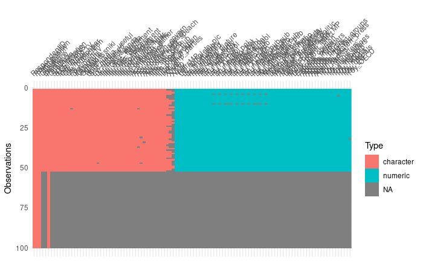

```r
df %>%
  visdat::vis_dat()
```

```r
table(df$Gender)
```

```
  Man Woman
   43     9
```

```r
table(df$`Power position`)
```

```
Government  Oposition
        61         39
```

Seems to me that the data are divided in

*demographic data*

[1] “RespondentID” “Power position” “Participation” “Year” “Gender”  
[6] “Language” “Parties” “YearsMP” “Chairman” “Specialisation”  
[11] “8.LETA/BNS”

*Some questions about use of social media*

“Monitoring” “Oft_radio_TV” “Oft_newspaper” “Oft_publication”  
[16] “FB” “draugiem.lv” “Instagram” “vkontakte” “Odnoklassniki”  
[21] “Twitter” “dont_use”

*some perceptions about their utility*

the rest of the columns

We can use an special package to create summary table ready for publication, it’s called gtsummary

```r
table(df$Gender, df$`Power position`)
```

```
        Government Oposition
  Man           30        13
  Woman          5         4
```

Learn about the package here: https://github.com/ddsjoberg/gtsummary

For example, a table of the demographic data by power position would be:

```r
pacman::p_load(gtsummary)
```

As you can see, there is *a lot* of data to clean here.

I *strongly suggest* you to learn two of the tidyverse packages:

https://stringr.tidyverse.org/

https://forcats.tidyverse.org/

# Questions

I don’t have much experience with this, so I google: https://www.google.com/search?q=lickert+data+r&oq=lickert+data+r&aqs=chrome..69i57.7470j0j1&sourceid=chrome&ie=UTF-8

I will subset the dataset, selecting some columns only

```r
df %>%
  select(`Power position`:Specialisation) %>%  # here I select the desired columns to summarize
  gtsummary::tbl_summary(by = `Power position`)
```

| **Characteristic** | **Government**, N = 61<sup>1</sup> | **Oposition**, N = 39<sup>1</sup> |
| --- | --- | --- |
| Participation |  |  |
| No | 26 (43%) | 22 (56%) |
| yes | 0 (0%) | 17 (44%) |
| Yes | 35 (57%) | 0 (0%) |
| Year | 1,963 (1,954, 1,971) | 1,964 (1,956, 1,973) |
| Unknown | 26 | 22 |
| Gender |  |  |
| Man | 30 (86%) | 13 (76%) |
| Woman | 5 (14%) | 4 (24%) |
| Unknown | 26 | 22 |
| Language |  |  |
| Latvian | 32 (91%) | 11 (65%) |
| Russian | 3 (8.6%) | 6 (35%) |
| Unknown | 26 | 22 |
| Parties |  |  |
| Frakcij? "No sirds Latvijai" | 0 (0%) | 7 (18%) |
| Frakcij? "Saska?a" | 0 (0%) | 24 (62%) |
| Frakcij?��Vienot?ba" | 23 (38%) | 0 (0%) |
| Latvijas Re?ionu apvien?bas frakcij? | 0 (0%) | 7 (18%) |
| Nacion?l? apvien?bas �Visu Latvijai!�-�T?vzemei un Br?v?bai/LNNK�frakcij? | 17 (28%) | 0 (0%) |
| Pie frakcij?m nepiedero�s deput?ts | 0 (0%) | 1 (2.6%) |
| Za?o un Zemnieku savien?bas frakcij? | 21 (34%) | 0 (0%) |
| YearsMP | 6 (4, 6) | 7 (3, 18) |
| Unknown | 26 | 22 |
| Chairman | 14 (40%) | 3 (18%) |
| Unknown | 26 | 22 |
| Specialisation |  |  |
| more than two | 25 (71%) | 11 (65%) |
| one or two | 10 (29%) | 6 (35%) |
| Unknown | 26 | 22 |

<sup>*1*</sup> Statistics presented: n (%); Median (IQR)

after googling some *hours* found some packages that can help to analyze Likert data

```r
mydf <- df %>%
  select(Journalists_indep:Agenda_written_press)
```

Please, read the documentation and options of the package here: https://cran.r-project.org/web/packages/sjPlot/sjPlot.pdf

Also you can order by some options, see page 25, the option sort.frq = from the plot_likert function

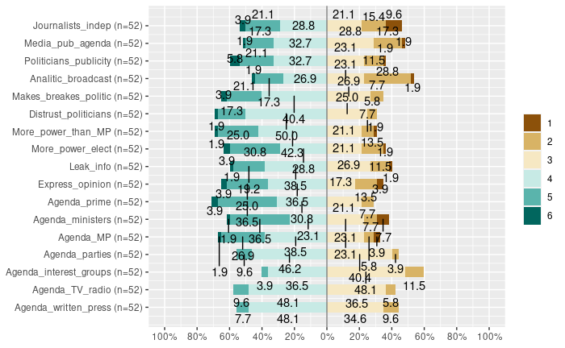

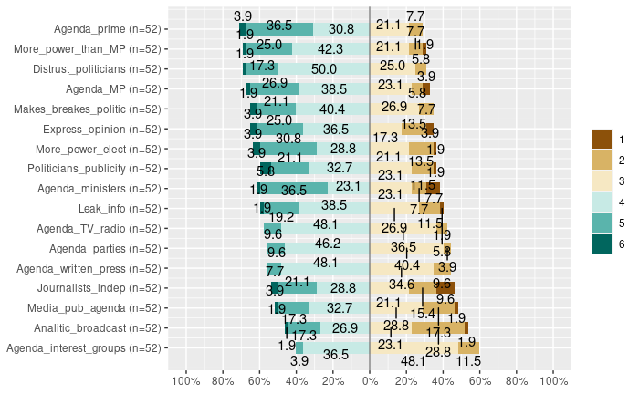

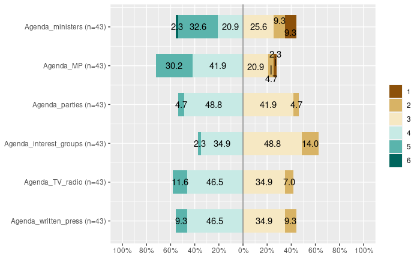

:)

# Learn more

learn about the sjPlot package here:

https://strengejacke.github.io/sjPlot/

# Learn even more!

Check the survey package, specially designed to analyze data from surveys

http://r-survey.r-forge.r-project.org/survey/

since is quite an old package, there is a tool that allows you to work with dplyr from tidyverse package:

https://github.com/gergness/srvyr